# CS 422 - HW 1

Mark Gameng, Illinois Institute of Technology

## Part 2.1

### (a)

```r
college <- read.csv("College.csv", row.names = 1)
college[1:5, c(1,5,8,10)]
```

|  | Private | Top10perc | P.Undergrad | Room.Board |
| --- | --- | --- | --- | --- |
| Abilene Christian University | Yes | 23 | 537 | 3300 |
| Adelphi University | Yes | 16 | 1227 | 6450 |
| Adrian College | Yes | 22 | 99 | 3750 |
| Agnes Scott College | Yes | 60 | 63 | 5450 |
| Alaska Pacific University | Yes | 16 | 869 | 4120 |

### (b)

```r
library(dplyr)
private <- dplyr::filter(college, Private == "Yes")
public <- dplyr::filter(college, Private == "No")
print(paste('There are', nrow(private), 'private colleges, and', nrow(public), 'public colleges in the dataset'))
```

```
[1] "There are 565 private colleges, and 212 public colleges in the dataset"
```

### (c)

```r
c_college <- college[, c("Private", "Apps", "Accept", "Enroll", "PhD", "perc.alumni", "S.F.Ratio", "Grad.Rate")]
head(c_college)
```

|  | Private | Apps | Accept | Enroll | PhD | perc.alumni | S.F.Ratio | Grad.Rate |
| --- | --- | --- | --- | --- | --- | --- | --- | --- |
| Abilene Christian University | Yes | 1660 | 1232 | 721 | 70 | 12 | 18.1 | 60 |
| Adelphi University | Yes | 2186 | 1924 | 512 | 29 | 16 | 12.2 | 56 |
| Adrian College | Yes | 1428 | 1097 | 336 | 53 | 30 | 12.9 | 54 |
| Agnes Scott College | Yes | 417 | 349 | 137 | 92 | 37 | 7.7 | 59 |
| Alaska Pacific University | Yes | 193 | 146 | 55 | 76 | 2 | 11.9 | 15 |
| Albertson College | Yes | 587 | 479 | 158 | 67 | 11 | 9.4 | 55 |

### (d)

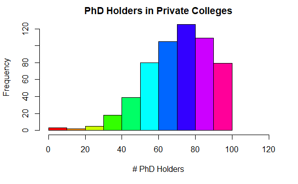

```r
priv <- hist(
  subset(c_college, Private == "Yes", select = c("PhD"))[, "PhD"],
  main = "PhD Holders in Private Colleges",
  xlab = "# PhD Holders",
  ylab = "Frequency",
  xlim = c(0,120),
  col = rainbow(length(priv$count)))
```

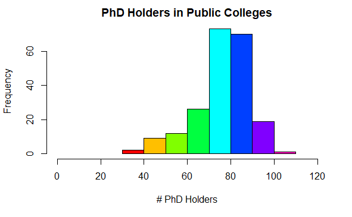

```r
pub <- hist(
  subset(c_college, Private == "No", select = c("PhD"))[, "PhD"],
  main = "PhD Holders in Public Colleges",
  xlab = "# PhD Holders",
  ylab = "Frequency",
  xlim = c(0, 120),
  col = rainbow(length(pub$count)))
```

### (e)

```r
sorted_college <- c_college[order(c_college$Grad.Rate),] # ascending
cat("Minimum graduation rates: ", rownames(sorted_college)[1:5],
    sep = "\n")
```

```
Minimum graduation rates:
Texas Southern University
Alaska Pacific University
Montreat-Anderson College
Brewton-Parker College
Claflin College
```

```r
cat("Maximum graduation rates: ", rownames(tail(sorted_college, 5)),
    sep = "\n")
```

```
Maximum graduation rates:
Missouri Southern State College
Santa Clara University
Siena College
University of Richmond
Cazenovia College
```

### (f)

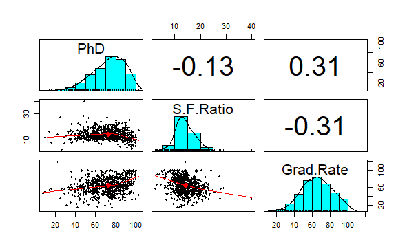

```r
library(psych)
pairs.panels(c_college[,c("PhD", "S.F.Ratio", "Grad.Rate")])
```

Grad.Rate and PhD have the highest correlation. It makes sense because if you are doing PhD, you’re probably invested into what you are studying due to it being like 6 years extra, and thus more likely to succeed and graduate.

Grad.Rate and S.F.Ratio have the lowest correlation. This negative correlation means, the higher the student faculty ratio, the less the graduation rate, which makes sense. The higher the student faculty ratio, the less time for one on one interaction between the students. With 1:1 ratio of student and faculty, means when a student needs help, they probably are able to get help from a faculty, meanwhile if it’s like 10:1, its much harder for the professor to help students.

### (g)

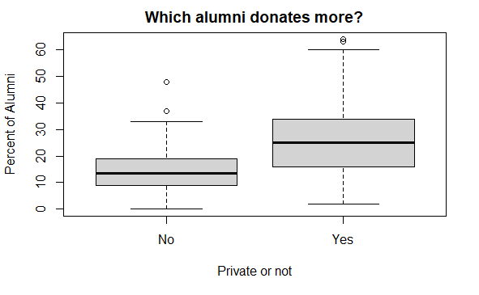

```r
boxplot(perc.alumni~Private, data = college,
        main = "Which alumni donates more?",
        ylab = "Percent of Alumni",
        xlab = "Private or not")
```

Private School alumni tends to donate more to their colleges than non-private. The mean and IQR of the % of alumni from private colleges are greater than the non-private.

### (h)

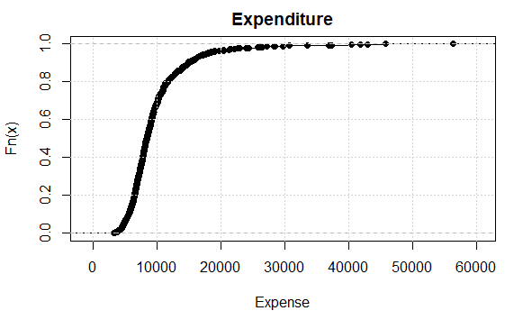

```r
cdf_function <- ecdf(college[,"Expend"])
plot(cdf_function,
     main = "Expenditure",
     xlab = "Expense")
grid()
```

Median expenditure per student seems to be about $9000.

80% of students pay less than about $12000.